# Clustering Credit Card Dataset

# Deskripsi data

1. CUSTID: Identitas Pemegang Kartu Kredit (Kategori)
2. BALANCE: Jumlah saldo yang tersisa di akun mereka untuk melakukan pembelian
3. BALANCEFREQUENCY: Seberapa sering Saldo diperbarui, skor antara 0 dan 1 (1 = sering diperbarui, 0 = tidak sering diperbarui)
4. PURCHASES: Jumlah pembelian yang dilakukan dari akun
5. ONEOFFPURCHASES: Jumlah pembelian maksimum dilakukan dalam sekali jalan
6. INSTALLMENTSPURCHASES: Jumlah pembelian yang dilakukan secara mencicil
7. CASHADVANCE: Uang tunai di muka yang diberikan oleh pengguna
8. PURCHASESFREQUENCY: Seberapa sering Pembelian dilakukan. Skor antara 0 dan 1 (1 = sering dibeli, 0 = tidak sering dibeli)
9. ONEOFFPURCHASESFREQUENCY: Seberapa sering Pembelian terjadi dalam sekali jalan (1 = sering dibeli, 0 = tidak sering dibeli)
10. PURCHASESINSTALLMENTSFREQUENCY: Seberapa sering pembelian secara mencicil dilakukan (1 = sering dilakukan, 0 = tidak sering dilakukan)
11. CASHADVANCEFREQUENCY: Seberapa sering uang tunai di muka dibayarkan
12. CASHADVANCETRX: Jumlah Transaksi yang dilakukan dengan “Cash in Advanced”
13. PURCHASESTRX : Banyaknya transaksi pembelian yang pernah dilakukan
14. CREDITLIMIT: Batas Kartu Kredit untuk pengguna
15. PAYMENTS: Jumlah Pembayaran yang dilakukan oleh pengguna
16. MINIMUM_PAYMENTS: Jumlah pembayaran minimum yang dilakukan oleh pengguna
17. PRCFULLPAYMENT: Persentase pembayaran penuh yang dibayarkan oleh pengguna
18. TENURE: Jangka waktu layanan kartu kredit untuk pengguna

Pengolahan Data menggunakan Open Source R

## Langkah 1 : Membaca data

```r
data <- read.csv("D:/Akademik/KMMI Bisnis Analitik/CC_GENERAL.csv",sep = ",")
```

## Langkah 2 : Melakukan statistika deskriptif dan preprocessing

```r
summary(data)
```

```
   CUST_ID             BALANCE        BALANCE_FREQUENCY   PURCHASES
 Length:8950        Min.   :    0.0   Min.   :0.0000    Min.   :    0.00
 Class :character   1st Qu.:  128.3   1st Qu.:0.8889    1st Qu.:   39.63
 Mode  :character   Median :  873.4   Median :1.0000    Median :  361.28
                    Mean   : 1564.5   Mean   :0.8773    Mean   : 1003.20
                    3rd Qu.: 2054.1   3rd Qu.:1.0000    3rd Qu.: 1110.13
                    Max.   :19043.1   Max.   :1.0000    Max.   :49039.57

 ONEOFF_PURCHASES  INSTALLMENTS_PURCHASES  CASH_ADVANCE
 Min.   :    0.0   Min.   :    0.0        Min.   :    0.0
 1st Qu.:    0.0   1st Qu.:    0.0        1st Qu.:    0.0
 Median :   38.0   Median :   89.0        Median :    0.0
 Mean   :  592.4   Mean   :  411.1        Mean   :  978.9
 3rd Qu.:  577.4   3rd Qu.:  468.6        3rd Qu.: 1113.8
 Max.   :40761.2   Max.   :22500.0        Max.   :47137.2

 PURCHASES_FREQUENCY ONEOFF_PURCHASES_FREQUENCY
 Min.   :0.00000     Min.   :0.00000
 1st Qu.:0.08333     1st Qu.:0.00000
 Median :0.50000     Median :0.08333
 Mean   :0.49035     Mean   :0.20246
 3rd Qu.:0.91667     3rd Qu.:0.30000
 Max.   :1.00000     Max.   :1.00000

 PURCHASES_INSTALLMENTS_FREQUENCY CASH_ADVANCE_FREQUENCY CASH_ADVANCE_TRX
 Min.   :0.0000                   Min.   :0.0000         Min.   :  0.000
 1st Qu.:0.0000                   1st Qu.:0.0000         1st Qu.:  0.000
 Median :0.1667                   Median :0.0000         Median :  0.000
 Mean   :0.3644                   Mean   :0.1351         Mean   :  3.249
 3rd Qu.:0.7500                   3rd Qu.:0.2222         3rd Qu.:  4.000
 Max.   :1.0000                   Max.   :1.5000         Max.   :123.000

 PURCHASES_TRX     CREDIT_LIMIT      PAYMENTS       MINIMUM_PAYMENTS
 Min.   :  0.00   Min.   :   50   Min.   :    0.0   Min.   :    0.02
 1st Qu.:  1.00   1st Qu.: 1600   1st Qu.:  383.3   1st Qu.:  169.12
 Median :  7.00   Median : 3000   Median :  856.9   Median :  312.34
 Mean   : 14.71   Mean   : 4494   Mean   : 1733.1   Mean   :  864.21
 3rd Qu.: 17.00   3rd Qu.: 6500   3rd Qu.: 1901.1   3rd Qu.:  825.49
 Max.   :358.00   Max.   :30000   Max.   :50721.5   Max.   :76406.21
                  NA's   :1                         NA's   :313
 PRC_FULL_PAYMENT     TENURE
 Min.   :0.0000   Min.   : 6.00
 1st Qu.:0.0000   1st Qu.:12.00
 Median :0.0000   Median :12.00
 Mean   :0.1537   Mean   :11.52
 3rd Qu.:0.1429   3rd Qu.:12.00
 Max.   :1.0000   Max.   :12.00
```

Dari data tersebut ditemukan missing value pada kolom CREDIT_LIMIT dan MINIMUM_PAYMENTS

Melihat grafik distribusi kolom CREDI_LIMIT dan MINIMUM_PAYMENTS untuk menentukan metode impute missing value

```
Warning: Removed 1 rows containing non-finite values (stat_bin).
Warning: Removed 1 rows containing non-finite values (stat_density).
```

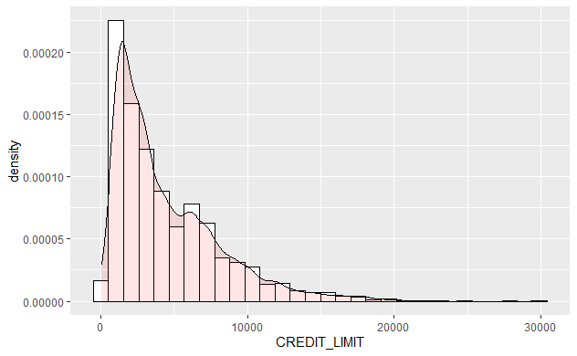

```r
library(ggplot2)
ggplot(data,aes(x=CREDIT_LIMIT))+
 geom_histogram(aes(y=..density..),colour="black", fill="white")+
 geom_density(alpha=0.1,fill="red")
```

```
Warning: Removed 313 rows containing non-finite values (stat_bin).
Warning: Removed 313 rows containing non-finite values (stat_density).
```

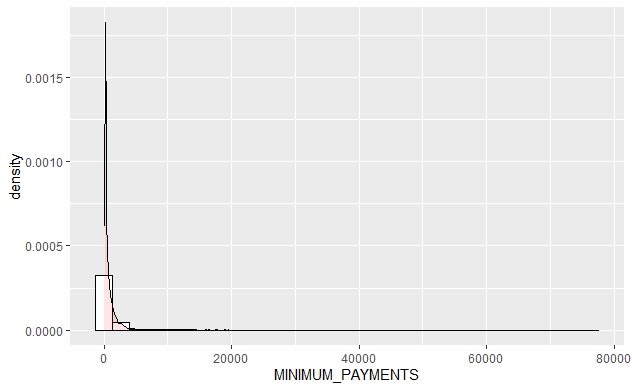

```r
ggplot(data,aes(x=MINIMUM_PAYMENTS))+
 geom_histogram(aes(y=..density..),colour="black", fill="white")+
 geom_density(alpha=0.1,fill="red")
```

Berdasarkan kedua gambar tersebut dapat diketahui bahwa variabel CREDIT_LIMIT dan MINIMUM_PAYMENTS tidak berdistribusi normal. Sehingga missing value dapat diatasi dengan melakukan imputasi menggunakan nilai median pada tiap variabel.

## Impute Missing Value

```r
data$CREDIT_LIMIT[is.na(data$CREDIT_LIMIT)] <- median(data$CREDIT_LIMIT, na.rm =
TRUE)
data$MINIMUM_PAYMENTS[is.na(data$MINIMUM_PAYMENTS)] <- median(data$MINIMUM_PAYMENTS, na.rm = TRUE)
```

```r
summary(data)
```

```
   CUST_ID             BALANCE        BALANCE_FREQUENCY   PURCHASES
 Length:8950        Min.   :    0.0   Min.   :0.0000    Min.   :    0.00
 Class :character   1st Qu.:  128.3   1st Qu.:0.8889    1st Qu.:   39.63
 Mode  :character   Median :  873.4   Median :1.0000    Median :  361.28
                    Mean   : 1564.5   Mean   :0.8773    Mean   : 1003.20
                    3rd Qu.: 2054.1   3rd Qu.:1.0000    3rd Qu.: 1110.13
                    Max.   :19043.1   Max.   :1.0000    Max.   :49039.57
 ONEOFF_PURCHASES  INSTALLMENTS_PURCHASES  CASH_ADVANCE
 Min.   :    0.0   Min.   :    0.0        Min.   :    0.0
 1st Qu.:    0.0   1st Qu.:    0.0        1st Qu.:    0.0
 Median :   38.0   Median :   89.0        Median :    0.0
 Mean   :  592.4   Mean   :  411.1        Mean   :  978.9
 3rd Qu.:  577.4   3rd Qu.:  468.6        3rd Qu.: 1113.8
 Max.   :40761.2   Max.   :22500.0        Max.   :47137.2
 PURCHASES_FREQUENCY ONEOFF_PURCHASES_FREQUENCY
 Min.   :0.00000     Min.   :0.00000
 1st Qu.:0.08333     1st Qu.:0.00000
 Median :0.50000     Median :0.08333
 Mean   :0.49035     Mean   :0.20246
 3rd Qu.:0.91667     3rd Qu.:0.30000
 Max.   :1.00000     Max.   :1.00000
 PURCHASES_INSTALLMENTS_FREQUENCY CASH_ADVANCE_FREQUENCY CASH_ADVANCE_TRX
 Min.   :0.0000                   Min.   :0.0000         Min.   :  0.000
 1st Qu.:0.0000                   1st Qu.:0.0000         1st Qu.:  0.000
 Median :0.1667                   Median :0.0000         Median :  0.000
 Mean   :0.3644                   Mean   :0.1351         Mean   :  3.249
 3rd Qu.:0.7500                   3rd Qu.:0.2222         3rd Qu.:  4.000
 Max.   :1.0000                   Max.   :1.5000         Max.   :123.000
 PURCHASES_TRX     CREDIT_LIMIT      PAYMENTS       MINIMUM_PAYMENTS
 Min.   :  0.00   Min.   :   50   Min.   :    0.0   Min.   :    0.02
 1st Qu.:  1.00   1st Qu.: 1600   1st Qu.:  383.3   1st Qu.:  170.86
 Median :  7.00   Median : 3000   Median :  856.9   Median :  312.34
 Mean   : 14.71   Mean   : 4494   Mean   : 1733.1   Mean   :  844.91
 3rd Qu.: 17.00   3rd Qu.: 6500   3rd Qu.: 1901.1   3rd Qu.:  788.71
 Max.   :358.00   Max.   :30000   Max.   :50721.5   Max.   :76406.21
 PRC_FULL_PAYMENT     TENURE
 Min.   :0.0000   Min.   : 6.00
 1st Qu.:0.0000   1st Qu.:12.00
 Median :0.0000   Median :12.00
 Mean   :0.1537   Mean   :11.52
 3rd Qu.:0.1429   3rd Qu.:12.00
 Max.   :1.0000   Max.   :12.00
```

```r
sum(is.na(data))
```

```
[1] 0
```

Dari hasil Summary diatas didapatkan missing value telah hilang

## Mengambil subset data tanpa kolom CUST_ID

```r
data <- subset(data, select = -CUST_ID)
```

```r
summary(data)
```

```
    BALANCE        BALANCE_FREQUENCY   PURCHASES        ONEOFF_PURCHASES
 Min.   :    0.0   Min.   :0.0000    Min.   :    0.00   Min.   :    0.0
 1st Qu.:  128.3   1st Qu.:0.8889    1st Qu.:   39.63   1st Qu.:    0.0
 Median :  873.4   Median :1.0000    Median :  361.28   Median :   38.0
 Mean   : 1564.5   Mean   :0.8773    Mean   : 1003.20   Mean   :  592.4
 3rd Qu.: 2054.1   3rd Qu.:1.0000    3rd Qu.: 1110.13   3rd Qu.:  577.4
 Max.   :19043.1   Max.   :1.0000    Max.   :49039.57   Max.   :40761.2
 INSTALLMENTS_PURCHASES  CASH_ADVANCE     PURCHASES_FREQUENCY
 Min.   :    0.0        Min.   :    0.0   Min.   :0.00000
 1st Qu.:    0.0        1st Qu.:    0.0   1st Qu.:0.08333
 Median :   89.0        Median :    0.0   Median :0.50000
 Mean   :  411.1        Mean   :  978.9   Mean   :0.49035
 3rd Qu.:  468.6        3rd Qu.: 1113.8   3rd Qu.:0.91667
 Max.   :22500.0        Max.   :47137.2   Max.   :1.00000
 ONEOFF_PURCHASES_FREQUENCY PURCHASES_INSTALLMENTS_FREQUENCY
 Min.   :0.00000            Min.   :0.0000
 1st Qu.:0.00000            1st Qu.:0.0000
 Median :0.08333            Median :0.1667
 Mean   :0.20246            Mean   :0.3644
 3rd Qu.:0.30000            3rd Qu.:0.7500
 Max.   :1.00000            Max.   :1.0000
 CASH_ADVANCE_FREQUENCY CASH_ADVANCE_TRX  PURCHASES_TRX     CREDIT_LIMIT
 Min.   :0.0000         Min.   :  0.000   Min.   :  0.00   Min.   :   50
 1st Qu.:0.0000         1st Qu.:  0.000   1st Qu.:  1.00   1st Qu.: 1600
 Median :0.0000         Median :  0.000   Median :  7.00   Median : 3000
 Mean   :0.1351         Mean   :  3.249   Mean   : 14.71   Mean   : 4494
 3rd Qu.:0.2222         3rd Qu.:  4.000   3rd Qu.: 17.00   3rd Qu.: 6500
 Max.   :1.5000         Max.   :123.000   Max.   :358.00   Max.   :30000
    PAYMENTS       MINIMUM_PAYMENTS   PRC_FULL_PAYMENT     TENURE
 Min.   :    0.0   Min.   :    0.02   Min.   :0.0000   Min.   : 6.00
 1st Qu.:  383.3   1st Qu.:  170.86   1st Qu.:0.0000   1st Qu.:12.00
 Median :  856.9   Median :  312.34   Median :0.0000   Median :12.00
 Mean   : 1733.1   Mean   :  844.91   Mean   :0.1537   Mean   :11.52
 3rd Qu.: 1901.1   3rd Qu.:  788.71   3rd Qu.:0.1429   3rd Qu.:12.00
 Max.   :50721.5   Max.   :76406.21   Max.   :1.0000   Max.   :12.00
```

# Langkah 3: Menentukan k Optimum

```r
library(factoextra)
```

## Elbow method

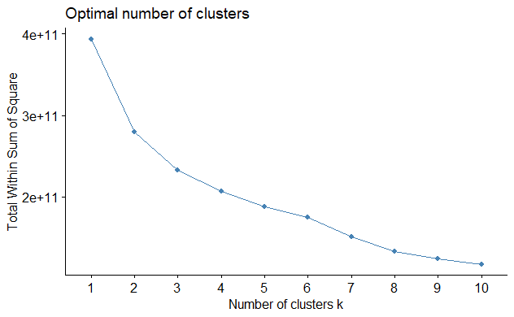

```r
fviz_nbclust(data, kmeans, method = "wss")
```

Penentuan nilai optimum dari metode elbow didapatkan dengan melihat grafik yang pertama melandai dimana pada gambar tersebut didapatkan 6 merupakan nilai optimum

## Silhouette method

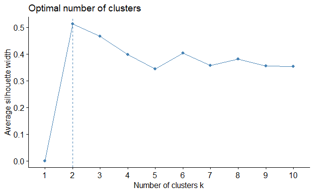

```r
fviz_nbclust(data, kmeans, method = "silhouette")
```

Silhouette didapatkan dengan melihat titik maksimum dimana pada gambar tersebut didapatkan 2 merupakan nilai optimum. Selain itu juga terdapat opsi dengan memilih titik tertinggi berikutnya. Sehingga dengan mempertimbangkan hasil metode Elbow ditentukan nilai optimumnya 6

# Langkah 4: Melakukan Analisis Cluster

## Clustering dengan nilai K=6

```r
set.seed(1)
kmeans_1 <- kmeans(data, 6)
```

```r
databind_1 <- cbind(data, Cluster = kmeans_1$cluster)
head(databind_1)
```

|  | BALANCE | BALANCE_FREQUENCY | PURCHASES | ONEOFF_PURCHASES | INSTALLMENTS_PURCHASES | CASH_ADVANCE | PURCHASES_FREQUENCY | ONEOFF_PURCHASES_FREQUENCY | PURCHASES_INSTALLMENTS_FREQUENCY | CASH_ADVANCE_FREQUENCY | CASH_ADVANCE_TRX | PURCHASES_TRX | CREDIT_LIMIT | PAYMENTS | MINIMUM_PAYMENTS | PRC_FULL_PAYMENT | TENURE | Cluster |
| --- | --- | --- | --- | --- | --- | --- | --- | --- | --- | --- | --- | --- | --- | --- | --- | --- | --- | --- |
| 1 | 40.90075 | 0.818182 | 95.40 | 0.00 | 95.40 | 0.000 | 0.166667 | 0.000000 | 0.083333 | 0.000000 | 0 | 2 | 1000 | 201.8021 | 139.5098 | 0.000000 | 12 | 6 |
| 2 | 3202.46742 | 0.909091 | 0.00 | 0.00 | 0.00 | 6442.945 | 0.000000 | 0.000000 | 0.000000 | 0.250000 | 4 | 0 | 7000 | 4103.0326 | 1072.3402 | 0.222222 | 12 | 5 |
| 3 | 2495.14886 | 1.000000 | 773.17 | 773.17 | 0.00 | 0.000 | 1.000000 | 1.000000 | 0.000000 | 0.000000 | 0 | 12 | 7500 | 622.0667 | 627.2848 | 0.000000 | 12 | 2 |
| 4 | 1666.67054 | 0.636364 | 1499.00 | 1499.00 | 0.00 | 205.788 | 0.083333 | 0.083333 | 0.000000 | 0.083333 | 1 | 1 | 7500 | 0.0000 | 312.3439 | 0.000000 | 12 | 2 |
| 5 | 817.71434 | 1.000000 | 16.00 | 16.00 | 0.00 | 0.000 | 0.083333 | 0.083333 | 0.000000 | 0.000000 | 0 | 1 | 1200 | 678.3348 | 244.7912 | 0.000000 | 12 | 6 |
| 6 | 1809.82875 | 1.000000 | 1333.28 | 0.00 | 1333.28 | 0.000 | 0.666667 | 0.000000 | 0.583333 | 0.000000 | 0 | 8 | 1800 | 1400.0578 | 2407.2460 | 0.000000 | 12 | 6 |

## Menampilkan nilai center dari setiap cluster dan kolom

```r
options(scipen = 9)
centers_1 <- data.frame(kmeans_1$centers)
centers_1$CLUSTER <- 1:nrow(centers_1)
centers_1s <- data.frame(t(centers_1[-18]))
colnames(centers_1s) <- centers_1[,18]
centers_1s
```

|  | 1 | 2 | 3 | 4 | 5 | 6 |
| --- | --- | --- | --- | --- | --- | --- |
| BALANCE | 4058.147688304 | 1949.6243431 | 2954.03905364 | 5519.04481808 | 6285.99096272 | 788.3379616 |
| BALANCE_FREQUENCY | 0.988636375 | 0.9050061 | 0.95077248 | 0.95963636 | 0.95948680 | 0.8500423 |
| PURCHASES | 1027.378750000 | 999.0328333 | 5678.44019651 | 26256.86280000 | 739.65659176 | 529.4002926 |
| ONEOFF_PURCHASES | 118.389464286 | 586.8651325 | 3757.68406114 | 21002.01880000 | 427.16765918 | 261.5573325 |
| INSTALLMENTS_PURCHASES | 908.989285714 | 412.3453376 | 1922.11421397 | 5254.84400000 | 312.61430712 | 268.1286762 |
| CASH_ADVANCE | 922.757849089 | 978.1427927 | 440.82494034 | 1491.96450136 | 6529.91949628 | 486.5800859 |
| PURCHASES_FREQUENCY | 0.471320321 | 0.5272163 | 0.88524878 | 0.91266664 | 0.34222885 | 0.4546770 |
| ONEOFF_PURCHASES_FREQUENCY | 0.039231554 | 0.2799116 | 0.66510190 | 0.80866672 | 0.15952310 | 0.1345110 |
| PURCHASES_INSTALLMENTS_FREQUENCY | 0.441152625 | 0.3595107 | 0.67879452 | 0.73199996 | 0.24892452 | 0.3492218 |
| CASH_ADVANCE_FREQUENCY | 0.105654714 | 0.1391136 | 0.06447662 | 0.05999996 | 0.45420957 | 0.1091783 |

[output cut: 7 more lines]

## Visualisasi Hasil Cluster

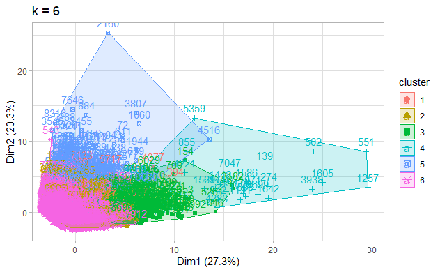

```r
g1 <- fviz_cluster(kmeans_1, geom = c("point", "text"), data = data) +
  ggtitle("k = 6") + theme_light()
plot(g1)
```

## Melihat nilai Mean, Median, dan Standar Deviasi dari setiap cluster

```r
library(dplyr)
data %>%
 group_by(kmeans_1$cluster) %>%
 summarise_all(funs(mean = mean, median = median, sd = sd)) %>%
 as.data.frame()
```

| kmeans_1$cluster | BALANCE_mean | BALANCE_FREQUENCY_mean | PURCHASES_mean | ONEOFF_PURCHASES_mean | INSTALLMENTS_PURCHASES_mean | CASH_ADVANCE_mean | PURCHASES_FREQUENCY_mean | ONEOFF_PURCHASES_FREQUENCY_mean | PURCHASES_INSTALLMENTS_FREQUENCY_mean | CASH_ADVANCE_FREQUENCY_mean | CASH_ADVANCE_TRX_mean | PURCHASES_TRX_mean | CREDIT_LIMIT_mean | PAYMENTS_mean | MINIMUM_PAYMENTS_mean | PRC_FULL_PAYMENT_mean | TENURE_mean | BALANCE_median | BALANCE_FREQUENCY_median | PURCHASES_median | ONEOFF_PURCHASES_median | INSTALLMENTS_PURCHASES_median | CASH_ADVANCE_median | PURCHASES_FREQUENCY_median | ONEOFF_PURCHASES_FREQUENCY_median | PURCHASES_INSTALLMENTS_FREQUENCY_median | CASH_ADVANCE_FREQUENCY_median | CASH_ADVANCE_TRX_median | PURCHASES_TRX_median | … |
| --- | --- | --- | --- | --- | --- | --- | --- | --- | --- | --- | --- | --- | --- | --- | --- | --- | --- | --- | --- | --- | --- | --- | --- | --- | --- | --- | --- | --- | --- | --- |
| 1 | 4058.148 | 0.9886364 | 1027.3788 | 118.3895 | 908.9893 | 922.7578 | 0.4713203 | 0.03923155 | 0.4411526 | 0.10565471 | 3.017857 | 18.625000 | 4267.857 | 1624.9391 | 22760.0316 | 0.001488089 | 11.91071 | 3401.1988 | 1 | 297.085 | 0.000 | 143.025 | 67.98893 | 0.3750000 | 0.000000 | 0.3333335 | 0.083333 | 1 | 7 | … |
| 2 | 1949.624 | 0.9050061 | 999.0328 | 586.8651 | 412.3453 | 978.1428 | 0.5272163 | 0.27991156 | 0.3595107 | 0.13911357 | 3.232051 | 15.977778 | 7233.477 | 1609.0933 | 709.2012 | 0.159700856 | 11.72692 | 1470.3541 | 1 | 623.285 | 233.195 | 100.790 | 0.00000 | 0.5634925 | 0.166667 | 0.1666670 | 0.000000 | 0 | 9 | … |
| 3 | 2954.039 | 0.9507725 | 5678.4402 | 3757.6841 | 1922.1142 | 440.8249 | 0.8852488 | 0.66510190 | 0.6787945 | 0.06447662 | 1.539301 | 65.349345 | 10521.616 | 5867.2524 | 1257.4938 | 0.295038247 | 11.94978 | 2017.3530 | 1 | 5165.685 | 3300.050 | 1346.275 | 0.00000 | 1.0000000 | 0.750000 | 0.8333330 | 0.000000 | 0 | 52 | … |
| 4 | 5519.045 | 0.9596364 | 26256.8628 | 21002.0188 | 5254.8440 | 1491.9645 | 0.9126666 | 0.80866672 | 0.7320000 | 0.05999996 | 2.440000 | 123.320000 | 16160.000 | 28433.7129 | 3222.0038 | 0.497424240 | 11.92000 | 3454.0943 | 1 | 25615.070 | 20646.070 | 4732.290 | 0.00000 | 1.0000000 | 1.000000 | 0.9166670 | 0.000000 | 0 | 101 | … |
| 5 | 6285.991 | 0.9594868 | 739.6566 | 427.1677 | 312.6143 | 6529.9195 | 0.3422289 | 0.15952310 | 0.2489245 | 0.45420957 | 14.846442 | 11.597378 | 10199.072 | 5833.6615 | 2200.5007 | 0.046197034 | 11.54494 | 6209.2564 | 1 | 189.850 | 0.000 | 0.000 | 5649.46251 | 0.1666670 | 0.000000 | 0.0000000 | 0.416667 | 11 | 2 | … |
| 6 | 788.338 | 0.8500423 | 529.4003 | 261.5573 | 268.1287 | 486.5801 | 0.4546770 | 0.13451103 | 0.3492218 | 0.10917825 | 2.284811 | 9.755463 | 2237.545 | 928.6876 | 505.0159 | 0.149851983 | 11.38450 | 533.1634 | 1 | 258.360 | 0.000 | 68.880 | 0.00000 | 0.4166670 | 0.000000 | 0.1666670 | 0.000000 | 0 | 6 | … |

## Clustering dengan nilai K=5

```r
kmeans_2 <- kmeans(data,5)
databind_2 <- cbind(data, Cluster = kmeans_2$cluster)
head(databind_2)
```

|  | BALANCE | BALANCE_FREQUENCY | PURCHASES | ONEOFF_PURCHASES | INSTALLMENTS_PURCHASES | CASH_ADVANCE | PURCHASES_FREQUENCY | ONEOFF_PURCHASES_FREQUENCY | PURCHASES_INSTALLMENTS_FREQUENCY | CASH_ADVANCE_FREQUENCY | CASH_ADVANCE_TRX | PURCHASES_TRX | CREDIT_LIMIT | PAYMENTS | MINIMUM_PAYMENTS | PRC_FULL_PAYMENT | TENURE | Cluster |
| --- | --- | --- | --- | --- | --- | --- | --- | --- | --- | --- | --- | --- | --- | --- | --- | --- | --- | --- |
| 1 | 40.90075 | 0.818182 | 95.40 | 0.00 | 95.40 | 0.000 | 0.166667 | 0.000000 | 0.083333 | 0.000000 | 0 | 2 | 1000 | 201.8021 | 139.5098 | 0.000000 | 12 | 4 |
| 2 | 3202.46742 | 0.909091 | 0.00 | 0.00 | 0.00 | 6442.945 | 0.000000 | 0.000000 | 0.000000 | 0.250000 | 4 | 0 | 7000 | 4103.0326 | 1072.3402 | 0.222222 | 12 | 2 |
| 3 | 2495.14886 | 1.000000 | 773.17 | 773.17 | 0.00 | 0.000 | 1.000000 | 1.000000 | 0.000000 | 0.000000 | 0 | 12 | 7500 | 622.0667 | 627.2848 | 0.000000 | 12 | 3 |
| 4 | 1666.67054 | 0.636364 | 1499.00 | 1499.00 | 0.00 | 205.788 | 0.083333 | 0.083333 | 0.000000 | 0.083333 | 1 | 1 | 7500 | 0.0000 | 312.3439 | 0.000000 | 12 | 3 |
| 5 | 817.71434 | 1.000000 | 16.00 | 16.00 | 0.00 | 0.000 | 0.083333 | 0.083333 | 0.000000 | 0.000000 | 0 | 1 | 1200 | 678.3348 | 244.7912 | 0.000000 | 12 | 4 |
| 6 | 1809.82875 | 1.000000 | 1333.28 | 0.00 | 1333.28 | 0.000 | 0.666667 | 0.000000 | 0.583333 | 0.000000 | 0 | 8 | 1800 | 1400.0578 | 2407.2460 | 0.000000 | 12 | 4 |

```r
centers_2 <- data.frame(kmeans_2$centers)
centers_2$CLUSTER <- 1:nrow(centers_2)
centers_2s <- data.frame(t(centers_2[-18]))
colnames(centers_2s) <- centers_2[,18]
centers_2s
```

|  | 1 | 2 | 3 | 4 | 5 |
| --- | --- | --- | --- | --- | --- |
| BALANCE | 4659.8832283 | 3488.10532665 | 1125.37101638 | 731.99522096 | 7100.07211507 |
| BALANCE_FREQUENCY | 0.9068250 | 0.95588544 | 0.89141885 | 0.84617650 | 0.97781851 |
| PURCHASES | 11810.7074775 | 580.86673401 | 1957.91753775 | 534.12732746 | 1447.32925156 |
| ONEOFF_PURCHASES | 8454.7751351 | 325.98231481 | 1261.20338560 | 261.70187592 | 787.99041580 |
| INSTALLMENTS_PURCHASES | 3356.1305405 | 254.91364478 | 697.25651568 | 272.72446219 | 659.47802495 |
| CASH_ADVANCE | 4867.1072735 | 2865.05554935 | 229.54634843 | 387.99776809 | 4798.06840754 |
| PURCHASES_FREQUENCY | 0.7723041 | 0.32661917 | 0.68331875 | 0.46317081 | 0.44669151 |
| ONEOFF_PURCHASES_FREQUENCY | 0.6301938 | 0.14279593 | 0.41897219 | 0.13679319 | 0.21971681 |
| PURCHASES_INSTALLMENTS_FREQUENCY | 0.6127218 | 0.22841796 | 0.47259562 | 0.35605349 | 0.35083672 |
| CASH_ADVANCE_FREQUENCY | 0.1956047 | 0.33319139 | 0.04538271 | 0.09847681 | 0.36870352 |

[output cut: 7 more lines]

```r
NA
```

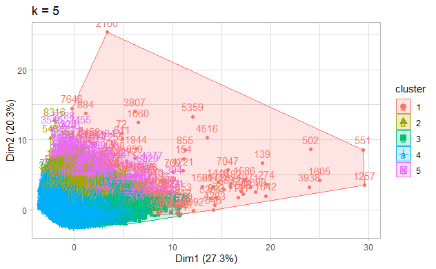

```r
g2 <- fviz_cluster(kmeans_2, geom=c("point","text"), data=data) +
  ggtitle("k = 5") + theme_light()
plot(g2)
```

```r
data %>%
 group_by(kmeans_2$cluster) %>%
 summarise_all(funs(mean = mean, median = median, sd = sd)) %>%
 as.data.frame()
```

| kmeans_2$cluster | BALANCE_mean | BALANCE_FREQUENCY_mean | PURCHASES_mean | ONEOFF_PURCHASES_mean | INSTALLMENTS_PURCHASES_mean | CASH_ADVANCE_mean | PURCHASES_FREQUENCY_mean | ONEOFF_PURCHASES_FREQUENCY_mean | PURCHASES_INSTALLMENTS_FREQUENCY_mean | CASH_ADVANCE_FREQUENCY_mean | CASH_ADVANCE_TRX_mean | PURCHASES_TRX_mean | CREDIT_LIMIT_mean | PAYMENTS_mean | MINIMUM_PAYMENTS_mean | PRC_FULL_PAYMENT_mean | TENURE_mean | BALANCE_median | BALANCE_FREQUENCY_median | PURCHASES_median | ONEOFF_PURCHASES_median | INSTALLMENTS_PURCHASES_median | CASH_ADVANCE_median | PURCHASES_FREQUENCY_median | ONEOFF_PURCHASES_FREQUENCY_median | PURCHASES_INSTALLMENTS_FREQUENCY_median | CASH_ADVANCE_FREQUENCY_median | CASH_ADVANCE_TRX_median | PURCHASES_TRX_median | … |
| --- | --- | --- | --- | --- | --- | --- | --- | --- | --- | --- | --- | --- | --- | --- | --- | --- | --- | --- | --- | --- | --- | --- | --- | --- | --- | --- | --- | --- | --- | --- |
| 1 | 4659.8832 | 0.9068250 | 11810.7075 | 8454.7751 | 3356.1305 | 4867.1073 | 0.7723041 | 0.6301938 | 0.6127218 | 0.19560468 | 8.4684685 | 88.270270 | 12630.180 | 19037.8715 | 2421.6443 | 0.36078185 | 11.90090 | 3123.3395 | 1 | 10903.220 | 6678.260 | 1650.710 | 0.000 | 1.000000 | 0.750000 | 0.750000 | 0.000000 | 0 | 70 | … |
| 2 | 3488.1053 | 0.9558854 | 580.8667 | 325.9823 | 254.9136 | 2865.0555 | 0.3266192 | 0.1427959 | 0.2284180 | 0.33319139 | 8.9149832 | 10.515152 | 5537.472 | 2447.1628 | 1987.2112 | 0.03391555 | 11.51431 | 3393.6093 | 1 | 123.465 | 0.000 | 0.000 | 2699.344 | 0.090909 | 0.000000 | 0.000000 | 0.292857 | 6 | 2 | … |
| 3 | 1125.3710 | 0.8914189 | 1957.9175 | 1261.2034 | 697.2565 | 229.5463 | 0.6833188 | 0.4189722 | 0.4725956 | 0.04538271 | 0.8815331 | 26.022067 | 8306.845 | 2154.4400 | 408.6704 | 0.26563611 | 11.82346 | 487.7467 | 1 | 1258.240 | 663.975 | 319.165 | 0.000 | 0.833333 | 0.333333 | 0.454545 | 0.000000 | 0 | 16 | … |
| 4 | 731.9952 | 0.8461765 | 534.1273 | 261.7019 | 272.7245 | 387.9978 | 0.4631708 | 0.1367932 | 0.3560535 | 0.09847681 | 1.9765051 | 9.911894 | 2266.533 | 848.5328 | 457.0796 | 0.15183799 | 11.39556 | 474.1438 | 1 | 266.680 | 0.000 | 78.045 | 0.000 | 0.416667 | 0.000000 | 0.166667 | 0.000000 | 0 | 6 | … |
| 5 | 7100.0721 | 0.9778185 | 1447.3293 | 787.9904 | 659.4780 | 4798.0684 | 0.4466915 | 0.2197168 | 0.3508367 | 0.36870352 | 10.9355509 | 21.939709 | 11623.502 | 4487.4258 | 3614.1505 | 0.02238855 | 11.71933 | 7005.3107 | 1 | 404.240 | 74.170 | 39.670 | 4109.465 | 0.333333 | 0.083333 | 0.083333 | 0.333333 | 8 | 6 | … |